# Diversity check_Sim Beta data

Shaoqian Huang

2026-09-22

## Aims

The document aims to check, under percentage cover data, (1) if the proposed diversity measure $\boldsymbol{\mu}_B^{\top}\boldsymbol{D}\boldsymbol{\mu}_B$ is a good measure of diversity. (2) if the proposed measure of diversity ($\boldsymbol{\mu}_B^{\top}\boldsymbol{D}\boldsymbol{\mu}_B$) is consistent with Rao’s Q and randomized Rao’s Q? (3) if the proposed measure of diversity estimator ($\hat{\boldsymbol{\mu}}_B^{\top}\boldsymbol{D}\hat{\boldsymbol{\mu}}_B$) is consistent with Rao’s Q and randomized Rao’s Q?

## DGM

### Set up parameters

```r
r <- 128 # sample size in each com
p <- 5 # the number of species
q <- 6 # the number of communities
## Mean abundance
mu=matrix(c(0.8,0.2,0.8,0.2,0.8,0.2,0.8,0.8,0.2,0.8,0.8,0.8,0.2,0.2,0.8,0.8,0.8,0.8,0.2,0.2,2/3,1/9,2/3,1/9,2/3, 0.8, 0.2, 0.2, 0.8, 0.8),ncol=6)
rownames(mu)=LETTERS[1:5]
colnames(mu)=1:q
mu <- t(mu)
print("--- Mean Abundance ---")
```

```
## [1] "--- Mean Abundance ---"
```

```r
print(mu)
```

```
##           A         B         C         D         E
## 1 0.8000000 0.2000000 0.8000000 0.2000000 0.8000000
## 2 0.2000000 0.8000000 0.8000000 0.2000000 0.8000000
## 3 0.8000000 0.8000000 0.2000000 0.2000000 0.8000000
## 4 0.8000000 0.8000000 0.8000000 0.2000000 0.2000000
## 5 0.6666667 0.1111111 0.6666667 0.1111111 0.6666667
## 6 0.8000000 0.2000000 0.2000000 0.8000000 0.8000000
```

```r
# Beta parameters for producing mu
alpha <- matrix(c(8, 2, 8, 2, 8,
                  2, 8, 8, 2, 8,
                  8, 8, 2, 2, 8,
                  8, 8, 8, 2, 2,
                  2, 1, 2, 1, 2,
                  8, 2, 2, 8, 8), nrow = 6, ncol = 5, byrow = TRUE
                )
colnames(alpha)=LETTERS[1:5]
beta <- matrix(c(2, 8, 2, 8, 2,
                 8, 2, 2, 8, 2,
                 2, 2, 8, 8, 2,
                 2, 2, 2, 8, 8,
                 1, 8, 1, 8, 1,
                 2, 8, 8, 2, 2), nrow = 6, ncol = 5, byrow = TRUE)

## Logit scale of mean abundance
eta <- logit(mu)

## Distance Matrix
D=matrix(c(0,1,2,3,4,1,0,2,3,4,2,2,0,3,4,3,3,3,0,4,4,4,4,4,0),ncol=5)
colnames(D)=rownames(D)=LETTERS[1:5]
print("--- Distance Matrix ---")
```

```
## [1] "--- Distance Matrix ---"
```

```r
print(D)
```

```
##   A B C D E
## A 0 1 2 3 4
## B 1 0 2 3 4
## C 2 2 0 3 4
## D 3 3 3 0 4
## E 4 4 4 4 0
```

```r
## An orthogonal projection matrix
J <- diag(rep(1, p)) -  1/p * matrix(1, p, p)

## eta_B
eta_B <- eta %*% J
mu_eta_B <- expit(eta_B)

## Expand alpha and beta parameter for calculating mean abundance matrix
# Expand alpha across sites
alpha_site <- alpha[rep(c(1 : q), each = r), ]
colnames(alpha_site)=LETTERS[1:5]
# Expand beta across sites
beta_site <- beta[rep(c(1 : q), each = r), ]
```

Based on David’s experiment, here I adopt Scenario 1 where there are 6 communities. Specifically, com 1 and com 2 have the same diversity, com 3 and com 4 decreases in diversity compared with com 1, com 5 retains the same level diversity as com 1 but decreases in overall abundance, and com 6 increases in diversity compared with com 1.

### Data Generation

```r
## Abundance matrix
abundance <- matrix(
  rbeta(length(alpha_site), alpha_site, beta_site),
  nrow = nrow(alpha_site),
  dimnames = dimnames(alpha)
)

# Create community factor (1:q repeated r times each)
com <- factor(rep(1:q, each=r))

# Combine abundance matrix and community labels into a data frame
yX <- data.frame(abundance, com)

## Long format abundance data
yX <- reshape(yX, direction = "long", varying = colnames(abundance),
              v.names = "y", timevar = "sp")

# Convert species column to factor
yX$sp <- factor(yX$sp)
```

## Modelling

```r
model <- glmmTMB (y ~ com * sp,
                  family = beta_family(),
                  data = yX)
```

## Model-based Diversity Assessment

### Extract fixed

```r
## Estimates of fixed effects, eta_T
eta_T_hat <- predict(model,
                   type = "link",
                   re.form = NA)

# Arrange eta_T_hat into a matrix
eta_T_hat <- matrix(
  as.numeric(eta_T_hat),
  ncol = p,
  byrow = FALSE
)

# Estimates of row centered fixed effects, eta_B
eta_B_hat <- eta_T_hat %*% J
```

### Dose $\mu_B^{\top}\boldsymbol{D}\mu_B$ can measure diversity correctly? Is it consistent with Rao’s Q and randomized Rao’s Q?

```r
## True diversity for reference
Div_TRUE <- rowSums(mu %*% D * mu)
print("--- TRUE Diversity ---")
```

```
## [1] "--- TRUE Diversity ---"
```

```r
print(Div_TRUE)
```

```
##        1        2        3        4        5        6
## 18.48000 18.48000 17.52000 13.44000 11.48148 19.68000
```

```r
## Model-based diversity
Div_Model <- rowSums(mu_eta_B %*% D * mu_eta_B)
print("--- Model ---")
```

```
## [1] "--- Model ---"
```

```r
print(Div_Model)
```

```
##        1        2        3        4        5        6
## 15.53312 15.53312 14.64182 10.88779 15.53312 16.61324
```

```r
## Rao's Q
Div_Rao <- rowSums((mu/apply(mu, 1, sum)) %*% D * (mu/apply(mu, 1, sum)))
print("--- RaosQ ---")
```

```
## [1] "--- RaosQ ---"
```

```r
print(Div_Rao)
```

```
##        1        2        3        4        5        6
## 2.357143 2.357143 2.234694 1.714286 2.325000 2.510204
```

```r
## Randomized Rao's Q
Div_rand_RaosQ <- randomization(
  abundance = mu,
  DM_phy_func = D
)
print("--- Randomized RaosQ ---")
```

```
## [1] "--- Randomized RaosQ ---"
```

```r
print(Div_rand_RaosQ)
```

```
##           1           2           3           4           5           6
##  0.48111797  0.45326763  0.04707696 -1.99937478  0.49705550  1.10307849
```

The results show that $\mu_B^{\top}\boldsymbol{D}\mu_B$ correctly measure the trend of absolute diversities of coms 1 - 6 and is insensitive to variation in total abundance, and is consistent with rao’s Q and randomized rao’s Q.

### If the proposed measure of diversity estimator ($\hat{\boldsymbol{\mu}}_B^{\top}\boldsymbol{D}\hat{\boldsymbol{\mu}}_B$) is consistent with Rao’s Q and randomized Rao’s Q?

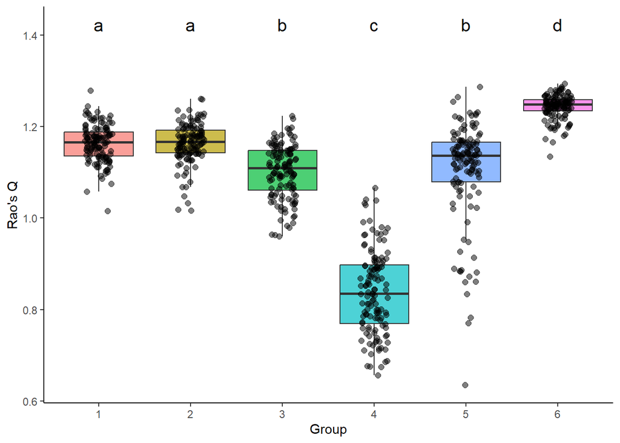

```r
## produce boxplot for RaosQ
RaosQ <- RaoQ(my.sample = abundance, DM = D)
RaosQ_data <- data.frame(
  group = com,
  value = RaosQ
)
fig_raosQ <- Boxplot(
  data = RaosQ_data,
  group_levels = c(
      "1",
      "2",
      "3",
      "4",
      "5",
      "6"
    ),
    ylab = "Rao's Q")
fig_raosQ
```

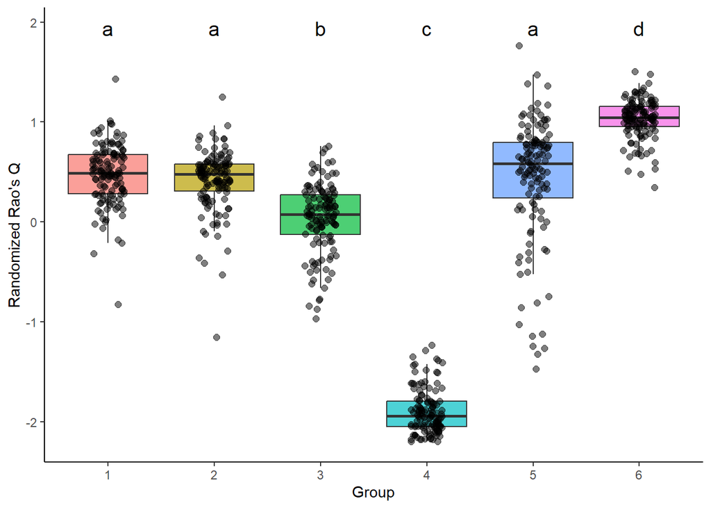

```r
## Produce boxplot for randomized RaosQ
RaosQ_rand <- randomization(
  abundance = abundance,
  DM_phy_func = D
)

# Combine randomized Rao's Q values with community groups.
RaosQ_rand_data <- data.frame(
  group = com,
  value = RaosQ_rand
)

fig1 <- Boxplot(data = RaosQ_rand_data,
                group_levels = c(
       "1",
      "2",
      "3",
      "4",
      "5",
      "6"),
    ylab = "Randomized Rao's Q")
fig1
```

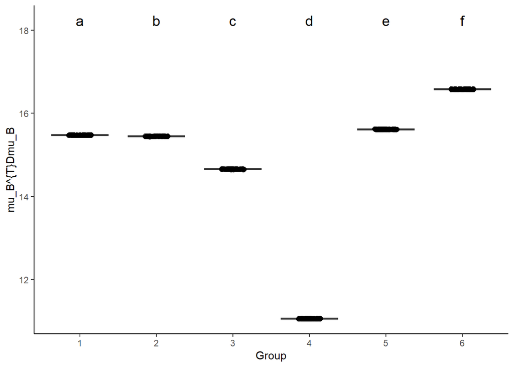

```r
## Produce boxplot for model-based diversity in each com
# Model-based Diversity Assessment
mu_eta_B_u_hat <- expit(eta_B_hat) # Ask David if RR or RR %*% J here?
Div_Model <-  rowSums(mu_eta_B_u_hat %*% D * mu_eta_B_u_hat)
Div_Model_data <- data.frame(
  group = com,
  value = Div_Model
)
Boxplot(data = Div_Model_data,
        group_levels = c(
          '1',
          '2',
          '3',
          '4',
          '5',
          '6'),
        ylab = "mu_B^{T}Dmu_B"
        )
```